# Tidymodels.org

# 1 Build a model {# Build-a-model}

## 1.1 Introduction

How do you create a statistical model using tidymodels? IN this article, we will walk you through the steps. We start with data for modeling, learn how to specify and train models with different engines using the parsnip package, and understand why these functions are desgined this way.

To use code in this article, you will need to install the following packages; readr, rstatnarm, and tidymodels.

```r
# tictoc::tic()
pacman::p_load(tidymodels, readr)
# tictoc::toc()
```

## 1.2 The Sea Urchins data

Let’s use the data from Constable(1993) to explore how three different feeding regimes affect the size of sea urchins over time. The initial size of the sea urchins at the beginning of the experiment probably affects how big they grow as they are fed.

To start, let’s rad our urchins data into R, which we’ll do by providing `readr::read_csv()` with a url where our CSV data is located (“https://tidymodels.org/start/models/urchins.csv”):

```r
urchins <-
  # Data were assembled for a tutorial
  # at https://www.flutterbys.com.au/stats/tut/tut7.5a.html
  read_csv("https://tidymodels.org/start/models/urchins.csv") %>%
  # chnge the names to be a little more verbose
  setNames(c("food_regime", "initial_volume", "width")) %>%
  # factors are very helpful for modeling, so we convert one column
  mutate(
    food_regime = factor(food_regime, levels = c("Initial", "Low", "High")))
urchins
```

```
## # A tibble: 72 x 3
##    food_regime initial_volume width
##    <fct>                <dbl> <dbl>
##  1 Initial                3.5 0.01
##  2 Initial                5   0.02
##  3 Initial                8   0.061
##  4 Initial               10   0.051
##  5 Initial               13   0.041
##  6 Initial               13   0.061
##  7 Initial               15   0.041
##  8 Initial               15   0.071
##  9 Initial               16   0.092
## 10 Initial               17   0.051
## # … with 62 more rows
```

The urchins data is a [tibble](https://tibble.tidyverse.org/index.html). If you are new to tibbles, they best place to start is the tibbles chapter in R for Data Science. For each of the 72 urchins, we know their:

- erimental feeding regime group (food_regime: either Initial, Low, or High),
- size in milliliters at the start of the experiment (initial_volume), and
- suture width at the end of the experiment (width).

As a first step in modeling, it’s always a good idea to plot the data:

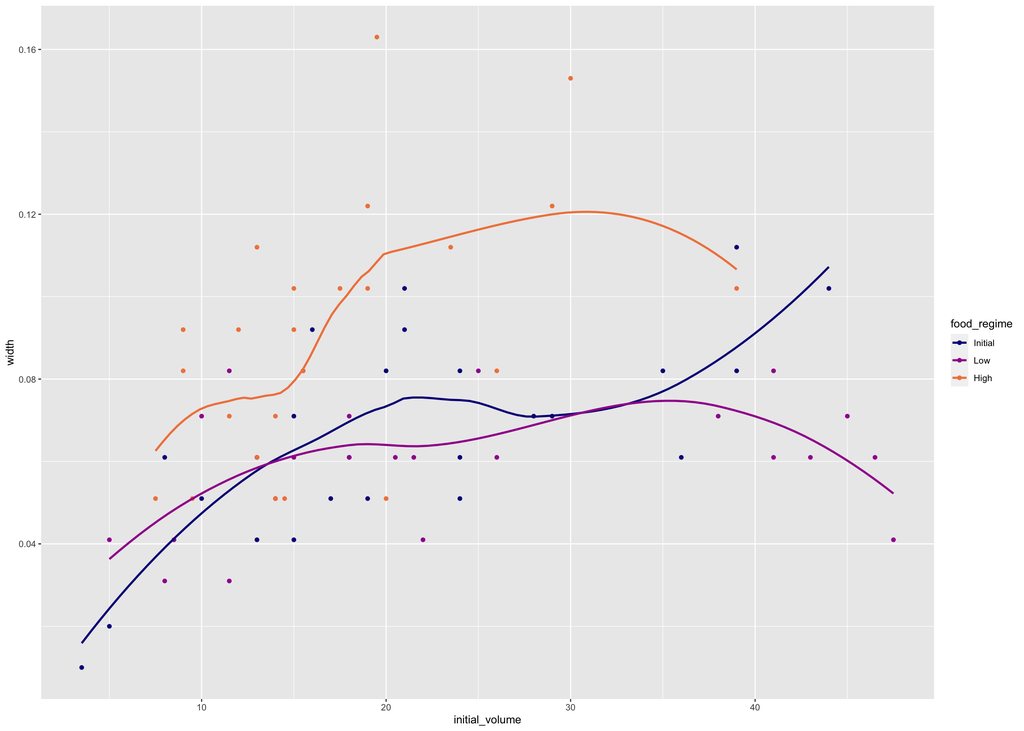

```r
ggplot(urchins,
  aes(x = initial_volume,
      y = width,
      group = food_regime,
      col = food_regime))+
  geom_point()+
  geom_smooth(se = FALSE, #method = lm
              )+
  # hrbrthemes::theme_ft_rc()
  scale_color_viridis_d(option = "plasma", end = .7)
```

We can see that urchins that were larger in volume at the start of the experiment tended to have wider sutures at the end, but the slopes of the lines look different so this effect may depend on the feeding regime condition.